# Analysis of RNA-seq data in R and Bioconductor

## DEXseq results.

We can specify the parameter **displayTranscripts** to TRUE to see the full gene model.

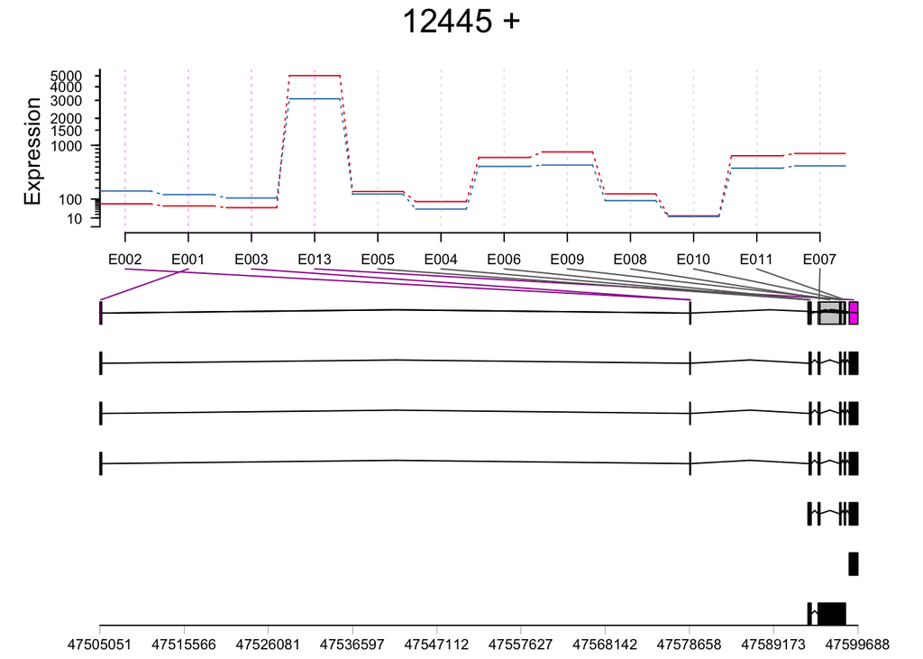

```r
plotDEXSeq(dxr1,"12445",displayTranscripts=TRUE)
```

## DEXseq results.

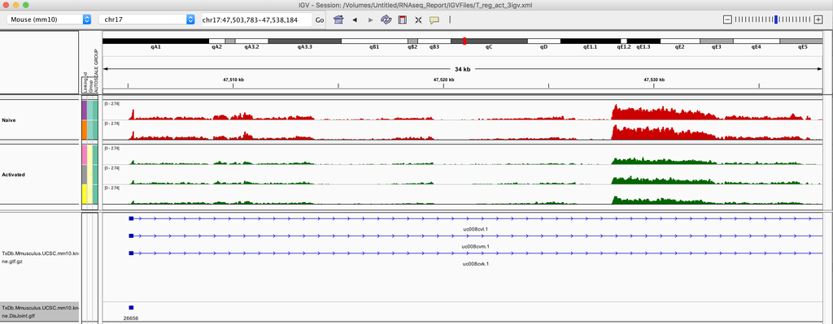

## DEXseq results- Gene Q values.

It may be desirable to obtain a pvalue summarising the differential exon usage to a gene level.

We can obtain an adjusted p-value per gene with the **perGeneQValue()** with our **DEXSeqResults** results object.

The result is a vector of adjusted p-values named by their corresponding gene.

```r
geneQ <- perGeneQValue(dxr1)
geneQ[1:10]
```

```
##    100017    100019 100033459 100034361 100036523 100036768 100037258
## 0.9856546 0.1869389 1.0000000 1.0000000 1.0000000 0.9354365 0.9687548
## 100037262 100037278 100037282
## 1.0000000 0.5459821 1.0000000
```

## RNAseq with multiple groups.

So far we have only reviewed a two group comparison of differential expression and differential transcript usage.

We can compare multiple groups fairly easily in DESeq2.

## RNAseq with multiple groups.

I load our precounted Tissues’ reads gene model and the loaded **RangedSummarizedExperiment** contains counts from three groups.

```r
load("../../Data/gC_TissueFull.RData")
geneCounts_Tissue
```

```
## class: RangedSummarizedExperiment
## dim: 24100 6
## metadata(0):
## assays(1): ''
## rownames(24100): 497097 19888 ... 100040911 170942
## rowData names(0):
## colnames(6): Sorted_Heart_1 Sorted_Heart_2 ... Sorted_Liver_1
##   Sorted_Liver_2
## colData names(0):
```

## RNAseq with multiple groups.

We can now set up our **DESeq2** object as we have previously and run the **DESeq** workflow function

```r
dds <- DESeqDataSet(geneCounts_Tissue,design = ~Tissue)
dds <- DESeq(dds)
```

## RNAseq with multiple groups.

To identify genes specifically upregulated in Heart versus other tissues. We can then overlap the upregulated genes from the Heart vs Liver and Heart vs Kidney comparisons.

First we convert **DESeqResults** objects into data.frame, remove NAs and extract most interesting columns to us.

```r
heartVsLiverDF <- as.data.frame(heartVsLiver)
heartVskidneyDF <- as.data.frame(heartVskidney)
heartVsLiverDF <- heartVsLiverDF[!is.na(heartVsLiverDF$padj),]
heartVskidneyDF <- heartVskidneyDF[!is.na(heartVskidneyDF$padj),]
heartVsLiverDF <- heartVsLiverDF[,c("log2FoldChange","padj")]
heartVskidneyDF <- heartVskidneyDF[,c("log2FoldChange","padj")]
```

## RNAseq with multiple groups.

Now we can extract our genes upregulated in Heart in both conditions.

```r
upInHeart <- fullTable$HeartVsLiver_log2FoldChange > 0 &
             fullTable$HeartVsKidney_log2FoldChange > 0 &
             fullTable$HeartVsLiver_padj < 0.05 &
             fullTable$HeartVsKidney_padj < 0.05
upInHeartTable <- fullTable[upInHeart,]
upInHeartTable[1:2,]
```

```
##    Row.names HeartVsLiver_log2FoldChange HeartVsLiver_padj
## 15 100038347                    4.950045      1.057860e-49
## 37 100038575                    2.454009      2.156496e-02
##    HeartVsKidney_log2FoldChange HeartVsKidney_padj
## 15                     4.342545       2.003331e-50
## 37                     3.161309       1.038031e-03
```

## RNAseq with multiple groups.

We can use **limmas’** **vennDiagram()** to produce a venn diagram of overlap in upregulation in heart vs Liver or Kidney.

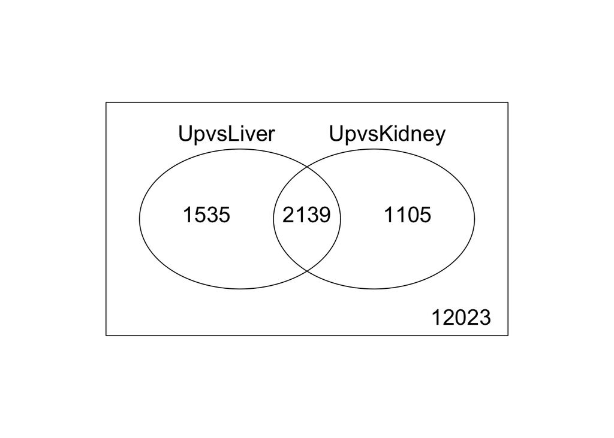

```r
library(limma)
vennDiagram(forVenn)
```

## RNAseq with multiple groups.

To compare out two models we must set the parameter of **reduced** to our alternative model of no groups. We also set the **test** parameter to **LRT** to allow us to compare the models.

```r
dds2 <- DESeq(dds,test="LRT",reduced=~1)
acrossGroups <- results(dds2)
acrossGroups <- acrossGroups[order(acrossGroups$pvalue),]
acrossGroups[1:3,]
```

```
## log2 fold change (MLE): Tissue Liver vs Heart
## LRT p-value: '~ Tissue' vs '~ 1'
## DataFrame with 3 rows and 6 columns
##        baseMean log2FoldChange     lfcSE      stat        pvalue
##       <numeric>      <numeric> <numeric> <numeric>     <numeric>
## 16483  125680.4      -2.294864 1.5830283  1642.173  0.000000e+00
## 17888   43583.9     -14.874592 0.6524674  1566.142  0.000000e+00
## 21956   16505.0     -15.058827 1.0578142  1430.916 1.908172e-311
##                padj
##           <numeric>
## 16483  0.000000e+00
## 17888  0.000000e+00
## 21956 1.095545e-307
```

## RNAseq with multiple groups.

We can combine our result with our previous table of pair-wise contrasts to provide information on where differences between groups exist.

```r
acrossGroups <- as.data.frame(acrossGroups[,c("pvalue","padj")])
colnames(acrossGroups) <- paste0("AllGroups","_",colnames(acrossGroups))
allGroups <- merge(fullTable,acrossGroups,by.x=1,by.y=0,all=TRUE)
allGroups <- allGroups[order(allGroups$AllGroups_pvalue),]
allGroups[1:2,]
```

```
##      Row.names HeartVsLiver_log2FoldChange HeartVsLiver_padj
## 5257     16483                    2.294864      2.469609e-01
## 6057     17888                   14.874592     1.633323e-111
##      HeartVsKidney_log2FoldChange HeartVsKidney_padj AllGroups_pvalue
## 5257                    -16.69262      2.113510e-140                0
## 6057                     14.84458      2.139909e-218                0
##      AllGroups_padj
## 5257              0
## 6057              0
```

# Time for an exercise.

Link_to_exercises

Link_to_answers